# Math 189: Classification via Discriminant Analysis I

# Classification

So far we have examined how to compare the means of more than two samples: - Multiple-sample testing - Analysis of variance (ANOVA) - Multivariate analysis of variance (MANOVA)

Next we study **classification**, with a particular focus on the *linear discriminant analysis* method. Some topics: 1. The classification problems 2. Bayes’ rule in classification 3. Linear discriminant analysis

# Qualitative variables

- Qualitative, or categorical, variables are very common in many datasets. They naturally reflect the discrete (or unordered) properties of observations.
- When a qualitative variable contains only two outcomes, it is also called a *binary variable*.

Examples of unordered variables: - Gender, blood type, smoking history, eye color of patients. - The political party that a voter might vote for. - Four nucleobases (A,G,T,C) of a DNA double helix. - Nationalities of students in a department. - Authenticity of a bank note (recall the swiss banknotes dataset). - Location of pottery shards (recall the pottery dataset).

# Classification

- The process to predict a qualitative variable is called *classification*. Or we can say that we classify that observation into a class/group/category. The statistical tools to classify the observations are called *classifiers*.

Examples: - A patient arrives at the emergency room with a set of symptoms that could possibly be attributed to one of the three medical conditions. Which one of the three does this patient have? - An online banking service must be able to determine whether or not a transaction being processed on the site is fraudulent, on the basis of the user’s IP address, transaction history, etc. - On the basis of DNA sequence data for a number of patients with and without a given disease, a biologist would like to determine which DNA mutations are dependent (disease-causing) and which are not.

## Classification versus Regression

Classification problems are different, but connected to regression problems!

### Classification

- Predict qualitative variables
- Rarely interested in population parameters
- With or without a response variable
- Many methods first predict the probability of each category. In this sense, they behave like regression methods

### Regression

- Predict quantitative variables
- Inference on population parameters
- Require a response variable to formulate the problem
- Response variable can be qualitative (e.g., logistic regression)

## Two Types of Classification

- In general, there are two types of classification problems: *supervised* and *un-supervised*, depending on whether we know (or partially know) the true values of the qualitative variables in the data.

### Supervised Classification

- We observed a sample in which we know the true class labels. We usually call this sample a *training set*.
- The true labels in the training set can “supervise” us to train a classifier.
- When we observe a sample without labelling, we can classify them using the classifier learned from the training set.

### Un-supervised Classification

- Sometimes we observe a sample without knowing the true class labels. Maybe there are no true class labels at all. There are also cases in which we do not even know how many groups/categories the variables belong to.
- We design a cost function based on the our objective. We classify the observations in order to minimize the cost function.
- Often, this is more challenging than supervised classification.

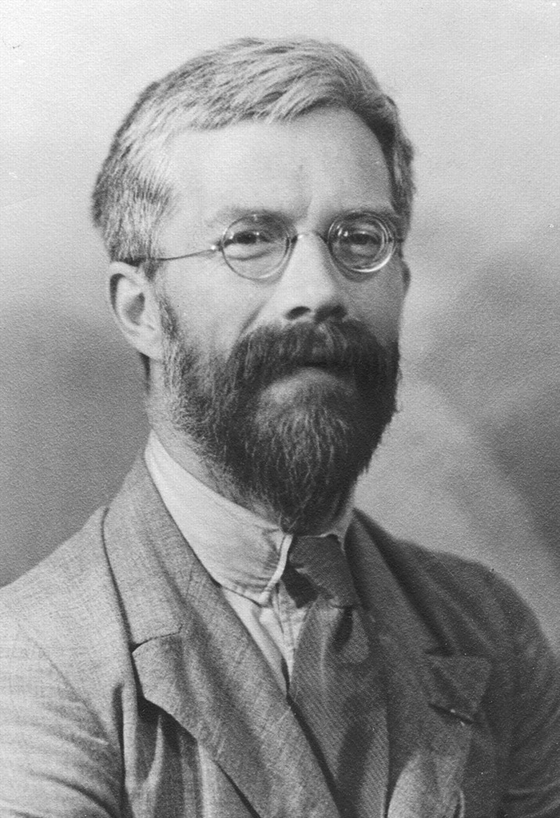

Fisher

## Linear Discriminant Analysis

- *Linear discriminant analysis* (LDA) is a statistical tool with an objective to solve a classification problem when the groups are known as a priori.
- LDA was developed (again!) by British statistician Ronald Fisher. Therefore, sometimes LDA is also called *Fisher’s Linear discriminant analysis*.
- LDA is different from ANOVA, as it is used to predict the group membership of an observation.
- LDA and ANOVA are closely related!

## Example: Iris Dataset

- In 1936, Fisher analyzed an iris flower dataset as an example of linear discriminant analysis. The dataset is collect by American botanist Edagar Anderson. So this dataset is usually called *Fisher’s Iris Data* or *Anderson’s Iris Data*.
- The iris dataset contains measurements for $150$ iris flowers from three different species:

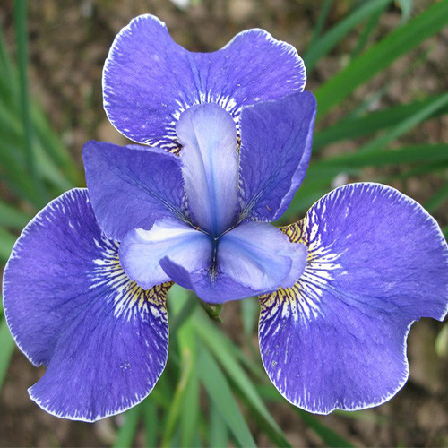

Iris-setosa

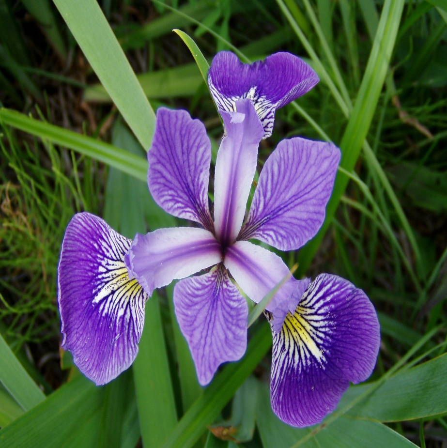

Iris-versicolor

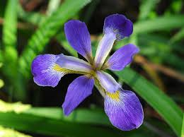

Iris-virginica

- Four variables were measured on each iris flower:
1. sepal length in cm
2. sepal width in cm
3. petal length in cm
4. petal width in cm

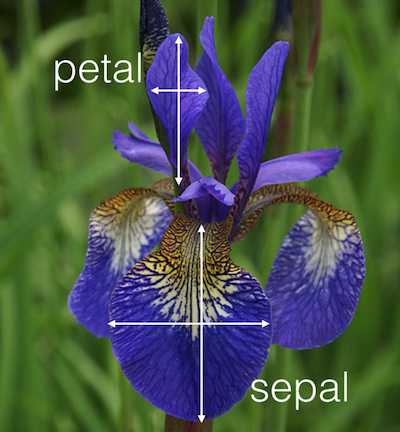

Iris-measurements

### Question

Based on the combination of these four features, can we develop a classifier for the iris flower, which can classify newly observed iris flowers into one of these three species?

## A Peek at the Data

- Dataset contains $150$ iris flowers from $3$ species.
- For each flower, the label of species is given and four features are measured.

```r
library(datasets)
data(iris)
iris.setosa <- iris[iris$Species == "setosa",]
iris.versi <- iris[iris$Species == "versicolor",]
iris.virgi <- iris[iris$Species == "virginica",]
rbind(iris.setosa[1:2,],iris.versi[1:2,],iris.virgi[1:2,])
```

|  | Sepal.Length | Sepal.Width | Petal.Length | Petal.Width | Species |
| --- | --- | --- | --- | --- | --- |
| 1 | 5.1 | 3.5 | 1.4 | 0.2 | setosa |
| 2 | 4.9 | 3.0 | 1.4 | 0.2 | setosa |
| 51 | 7.0 | 3.2 | 4.7 | 1.4 | versicolor |
| 52 | 6.4 | 3.2 | 4.5 | 1.5 | versicolor |
| 101 | 6.3 | 3.3 | 6.0 | 2.5 | virginica |
| 102 | 5.8 | 2.7 | 5.1 | 1.9 | virginica |

# Bayes’ Rule

- The idea of LDA originated from a classic result in probability theory, called *Bayes’* rule.
- Consider any two events $A$ and $B$. The probability that $B$ occurs given that $A$ has occurred, has the following definition:
  $${\mathbb P} [ B \vert A] = \frac{{\mathbb P} [ B \cap A ] }{ {\mathbb P} [A]},$$
  when ${\mathbb P}[A] > 0$.
- This says that the conditional probability ${\mathbb P} [ B \vert A]$ is the probability that both $A$ and $B$ occur, divided by the unconditional probability that $A$ occurs.
- Some simple algebra yields
  $${\mathbb P} [ B \cap A ] = {\mathbb P} [ B \vert A] \, {\mathbb P} [A]
  = {\mathbb P} [ A \vert B] \, {\mathbb P} [B].$$

## Some Notations

- Suppose that we have $g$ populations (groups), and $Y$ is a univariate discrete random variable that indicates the group membership, i.e. $Y \in \{ 1,2, \ldots, g \}$.
- Let $p_k = {\mathbb P} [ Y = k]$ be the probability mass function that a randomly selected observation is in population $k$. $p_k$ is usually called the *prior probability*.
- Let $f( \underline{X} = \underline{x} \vert Y = k)$ be the conditional probability density function of a multivariate random variable $\underline{X}$ with observed value $\underline{x}$, given that the observation came from population $k$.
- Let $p(Y = k \vert \underline{X} = \underline{x})$ be the conditional probability mass function that an observation is a member of population $k$, given $\underline{x}$. The quantity $p(Y = k \vert \underline{X} = \underline{x})$ is usually called the *posterior probability*.

## Bayes’ Rule for Classification

- According to Bayes’ rule, we have the following relationship between the prior probability and posterior probability:
  $$p(Y = k \vert \underline{X} = \underline{x}) = \frac{ p(Y = k, \underline{X} = \underline{x})}{ f (\underline{X} = \underline{x})}
  = \frac{ p_k \, f( \underline{X} = \underline{x} \vert Y = k) }{
  = \sum_{h=1}^g p_h \, f( \underline{X} = \underline{x} \vert Y = h) }.$$
- The numerator gives the likelihood that a randomly selected observation $\underline{x}$ comes from population $k$.
- The denominator is the unconditional likelihood (over all populations) that we could observe $\underline{x}$.
- The posterior probability is the probability that an observation $\underline{x}$ belongs to the $k$th group.
- A natural classification rule is to classify the observation $\underline{x}$ into the group with highest posterior probability. This is called the **Bayes’ classifier**.
- Note that the denominator term is the same for all groups and $\log$ is a monotonic transformation; so finding the highest posterior probability corresponds to finding the group with highest log-likelihood:
  $$\log \left( p_k \, f( \underline{X} = \underline{x} \vert Y = k) \right).$$

## A Classification Rule

- Find the group membership that maximizes a *discriminant function*:
  $$d_k (\underline{x}) = \log \left( p_k \, f( \underline{X} = \underline{x} \vert Y = k) \right), \quad k = 1, 2, \ldots, g.$$
- Assumptions for the LDA are similar to those for MANOVA:
1. The data from group $k$ has common mean vector $\underline{\mu}^{(k)}$, i.e.,
   $${\mathbb E} [ x_{ij}^{(k)} ] = \underline{\mu}_j^{(k)}.$$
   (The $m$ components of the vector correspond to the $m$ variables.)
2. Homoskedasticity: The data from all groups have common covariance matrix ${\mathbf \Sigma}$, i.e.,
   $${\mathbf \Sigma} = \mbox{Cov} [ \underline{x}_i^{(k)}, \underline{x}_i^{(k)}]$$
   for any record $i$, and the matrix does not depend on $k$ (the group index).
3. Independence: The observations are independently sampled.
4. Normality: The data are multivariate normally distributed.

## Discriminant Analysis Procedure

- In general, the procedure of discriminant analysis can be summarized as follows:
1. *Collect training data*: Training data are data with known group memberships. For example, in the Swiss Bank Notes dataset, we know which notes are genuine and which are counterfeit.
2. *Choose prior probability*: We calculate or assign prior probability $p_k = {\mathbb P} [ Y = k]$ for each group.
3. *Estimate the parameters of $f( \underline{X} = \underline{x} \vert Y = k)$*: Under the assumptions stated above, we assume the conditional probability density function $f( \underline{X} = \underline{x} \vert Y = k)$ is the density function of a multivariate normal distribution.
4. *Calculate the discriminant function*: calculate $d_k (\underline{x}) = \log ( p_k \, f( \underline{X} = \underline{x} \vert Y = k) )$ for each $1 \leq k \leq g$.
5. *Classify observation*: observation $\underline{x}$ gets classified to a group $k$ with highest discriminant $d_k (\underline{x})$.

### Choose Prior Probability

The prior probability $p_k = {\mathbb P} [ Y = k]$ represents the expected portion of the community that belongs to group $k$. There are three common choices: 1. Equal priors:
$$p_k = 1/g.$$
Equal priors are useful if we believe that all of the population sizes are more or less the same. 2. Arbitrary priors: any combination that satisfies
$$p_1 + p_2 + \ldots + p_g = 1.$$
Arbitrary priors are usually selected according to the investigator’s beliefs regarding the relative population sizes. 3. Training data priors:
$$p_k = n_k/N.$$
Training data priors are selected if we believe the relative sample sizes in the training data are close to the relative population sizes.